# Coursework Report

*N* removed NAs: 2

*N* removed typo: 1

*N* removed <18: 14

[output not shown]

**Main analysis results**

[interactive chart not shown]

[figure not shown]

[interactive chart not shown]

# Coursework Report

Analysing Data, Spring 2020

```
## tibble [150 x 6] (S3: tbl_df/tbl/data.frame)
##  $ id       : Factor w/ 150 levels "ABTM","ACZL",..: 38 39 87 4 45 6 42 105 64 127 ...
##  $ condition: Factor w/ 3 levels "control","experimental",..: 2 2 2 2 2 2 2 2 2 2 ...
##  $ age_years: chr [1:150] "17" "23" "24" "21" ...
##  $ item_1   : num [1:150] 7 8 8 7 5 5 6 5 7 4 ...
##  $ item_2   : num [1:150] 8 6 5 6 6 5 8 8 5 7 ...
##  $ item_3   : num [1:150] 5 5 5 5 4 8 7 6 7 6 ...
```

# Methods

## Participants

**Figure 1:**

```
## # A tibble: 2 x 5
##   condition     mean    sd   min   max
##   <fct>        <dbl> <dbl> <dbl> <dbl>
## 1 control       20.8  2.20    18    25
## 2 experimental  20.9  1.92    18    25
```

## Design

The conceptual hypothesis for this experiment was that colour affects levels of attractiveness in males. The hypothesis was operationalised by asking participants to rate attractiveness levels after being shown a photo of a moderately attractive male with a background of one of two colours (red or white). This experiment was a replication of the Elliot et al (2010) experiment, therefore, the same design and materials were used. An independent group design was used: participants were randomly assigned to one of two conditions. Participants viewed a 4in x 6in photo of the same man in the Elliot et al (2010) experiment. The photo was in black and white and had either a red (experimental condition) or white (control condition) background (the photo was centred on 8.5in x 11in card). The participants were allowed to view the photo for 5 seconds. The independent variable in this experiment was the two different coloured backgrounds red and white. The dependant variable was the levels of attractiveness. To investigate this the following questions were asked: “How attractive do you think this person is?”, “How pleasant is this person to look at?”, “If I were to meet the person in this picture face to face, I would think he is attractive.” These questions were measured by participants rating the man in the picture on a 9-point scale rating; 1 being not at all attractive and 9 being extremely attractive. Therefore, a high rating on the 9-point scale meant the participant believed the male was very attractive. The operational hypothesis for this experiment was; colour effects attractiveness rating of males. And the analysis carried out to investigate this was a t distribution to compare the means of the two independent conditions.

# Results

To replicate Elliot et al’s (2010) experiment, a composite index of perceived attractiveness was created; this showed the mean for all three items tested. The results showed little difference between participants in the experimental condition who were exposed to the photo with a red background ( M = 6.13, SD = 1.38) compared with participants in the control condition who were exposed to the white background (M = 6.09, SD = 1.19). This suggested the mean of ratings were not statistically significant.

**Figure 2**

```
## # A tibble: 2 x 7
##   condition     mean median    sd variance   min   max
##   <fct>        <dbl>  <dbl> <dbl>    <dbl> <dbl> <dbl>
## 1 control       6.09      6  1.19     1.42     4     9
## 2 experimental  6.13      6  1.38     1.91     3     9
```

**Figure 3**

```
##
##  Two Sample t-test
##
## data:  attractive_comp by condition
## t = -0.17973, df = 129, p-value = 0.8576
## alternative hypothesis: true difference in means is not equal to 0
## 95 percent confidence interval:
##  -0.4872669  0.4061101
## sample estimates:
##      mean in group control mean in group experimental
##                   6.093750                   6.134328
```

This means that there was not a significant difference between the two independent variables. It is likely that the small difference that did occur, happened by chance. These results, therefore, suggest that red did not affect levels of attractiveness.

**Figure 4**

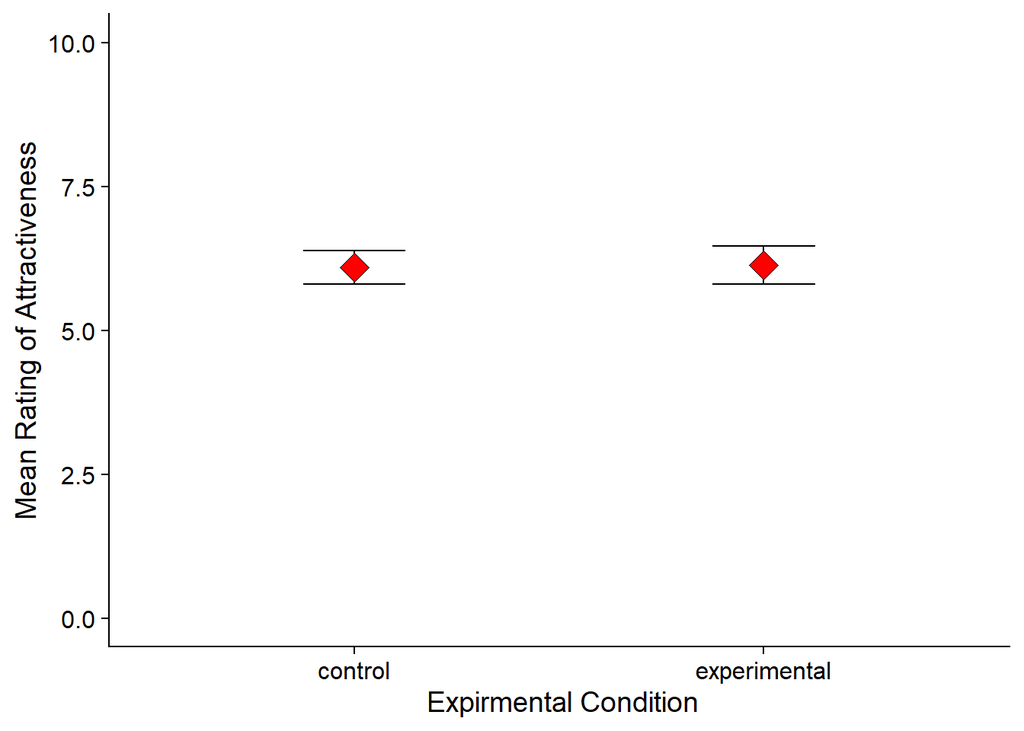

# Discussion

The current experiment shows that there was an insignificant difference between the two colours red and white. This suggest that colour does not affect levels of perceived attractiveness. These results therefore contradict Elliot et al’s (2010) experiment which found a significant difference that red increased mean attractiveness ratings. attractiveness in males.

One difference between the current experiment and Elliot et al’s (2010) experiment is a much larger sample was used. The number of participants used in Elliot et al’s (2010) experiment was only 21 whereas, 131 participants where included in the current experiment; therefore, the current experiment had a sample size that was more representative of the population. This strengthens the experiment because the use of a larger sample size reduces the uncertainty that results only occurred by chance, which can occur in experiments that use a small sample size (Biau, Kerneis, Porcher, 2008).

One limitation to this experiment is only one photo of a moderately attractive Caucasian man was used. This could limit the extent that red influences attractiveness levels because red may only enhance attractiveness when the participant views the person as already attractive. Young (2015) investigated the effect red has on attractiveness. However, prior to being exposed to the introduction of colours; participants took part in a baseline study where they had to state if the they found the person in the photos as attractive or unattractive. It was found that red enhanced levels of attractiveness, only when the participants had already stated the person as attractive. Red had no influence on faces rated as unattractive. Therefore, A possible reason why red did not significantly enhance attractiveness in the current experiment is because the participants might not have viewed the man as attractive in the first place, thus as suggested by Young (2015) red would have no influence on perceived attractiveness. By using only one photo of an average looking man the experiment is limiting the extent to how much the red effect can be investigated. To improve the experiment, a larger range of photos of different men varying in levels of attractiveness should be used to investigate if red enhances attractiveness of a person who is already considered attractive.

However, the results from this experiment are consistent with other experiments in this area. Peperkoon, Roberts and Pollet (2016) investigated the effect of a woman wearing red had on attractiveness levels. They found no significant differences on attractiveness levels when paired with different colours. This contradicts the hypotheses that the women in red would be rated as more attractive. Furthermore, Hesslinger, Goldbach and Carbon (2015) who replicated Elliot et al’s 2010 experiment found also, that red did not affect attractiveness levels.

These experiments (including the current experiment) , show the consistent result that red had no significant effect of the mean rating of attractiveness. Therefore, it appears that Elliot’s proposal that red increases perceived attractiveness is not true. However, there are other areas of research that the current experiment did not consider that suggest that red could play a small role in increasing perceived attractiveness.

Possible further research to be conducted could consider the effect red has when it is physically present on the person. The experiment conducted used a red card as a background for a black and white photo. Therefore, red appeared only as a non-physical association with the photo. Red was not an apparent physical feature of the person so the association of attractiveness with red being physically present was not tested.  
In animals red pigmentation is consistently considered as an important feature in a desired mate. Dubac, Allen, Maestripieri and Hingham (2014) found that in Rhesus monkeys, males who had dark red pigmentations on their face were preferred by female monkeys than those who had pale pink faces. Furthermore, Burley, Krantzberg and Randman (1982) found that female zebra finches showed preferences for males who displayed red leg bands, due to their association with bright red beaks being considered the most attractive feature in a male zebra finch. This suggest that natural red pigmentation on animals enhances attractiveness. Furthermore, there is research conducted by Stephen, Coetzee, Law Smith and Perrett (2009) who found that red pigmentation of the skin in humans led to associations with good health status, which strongly influenced levels of attractiveness. This could indicate a link that the colour red being physically present on a person skin increases attractiveness due to its positive conations with health. Therefore, further research into the link between red skin pigmentation and attractiveness should be investigated to see if an effect occurs.

Another pathway for further research could involve investigating the possible effect different colours has on attractiveness levels. Kramer and Mulgrew (2017) found that both men and women choose to wear black more than any other colour on first dates. Furthermore, Peperkoon (2016) found that the colour black does increase levels of attractiveness in a long-term scenario. Roberts et al (2016) also found that the colour black was associated with higher levels of fashionableness which leads to positive influences on attractiveness levels. This association with fashionableness takes a different cognitive pathway than the associations of sexual connotations that comes with red. Therefore, research into this area may be beneficial because, although red was found not to increase levels of attractiveness in the current experiment; it is still possible that black could effect attractiveness due to the different cognitive pathways it takes.

To conclude, the current experiment was a replica of Elliot et al (2010) experiment. The aim was to investigate the effect red has on levels of attractiveness when compared with white. Despite replicating Elliot et al’s (2010) experiment the results in the current experiment found no significant difference between the two colours. This suggests that red does not increase levels of attractiveness. Thus contradicting Elliot et al’ s findings. The current experiment results are consistent with other experiments that investigated this area: which found no significant difference, further suggesting that colour does not play a large role in influencing attractiveness. However, the current experiment used different coloured cards to back the black and white photo, therefore did not investigate the physical presence of red on an individual’s body. This means the results cannot comment on the possible influence of red being physically present on person has on attractiveness therefore, more research should be undertaken into this possibility. Furthermore, to improve the current experiment a larger sample of different photos of men should be used to investigate how red effects different ranges attractiveness; as this could not be investigated in the current experiment due to its use of only one photo. And also, more research should be conducted to see the influence that different colours have on attractiveness. But, as it stands, the findings from the current experiment suggest red has no effect on perceived attractiveness.

# References

Biau, D.J., Kerneis, S., Porchet, R. (2008) ‘ Statistics in Brief: The Importance of Sample Size in the Planning and Interpretation of Medical Research’ Clinical Orthopaedics and Related Resrach’ 466(9), 2282-2288

Burley, N., Krantzberg, G., Radman, P., (1982), ‘Influence of Colour- Banding on the Conspecific Preferences of Zebra Finches’, Animal Behaviour, 30(2), 444-455

Dubac, C., Allen, W.L., Maestripieri, D., Higham, J.P. (2014) ‘Is male rhesus macaque red color ornamentation attractive to females?’ Behavioural and Sociobiology 68(7), 1215-1224

Elliot, A., Greitemeyer, T., Gramzow, R., Niesta Kayser, D., Lichtenfeld, S., Maier, m., Liu, H. (2010) ‘Red, Rank, and Romance in Women Viewing Men.’, Journal of Experimental Psychology: General, 139(3), 399-417.

Hesslinger, V.M., Goldbach, L., Carbon, C. (2015) ‘Men in red: A re-examination of the red attractiveness effect’ Psychonomic Bulletin and Review, 22(4), 1142-1148

Kramer, R.S.S., Mulgrew, J., (2018) ‘Displaying Red and Black on a First Date: A Fiel,d Study Using the “First Dates” Television series’, Evolutionary Psychology, 16(2)

Pazda, A.D., Elliot, A.J., Greitemeyer, (2013) ‘Perceived sexual receptivity and fashionableness: Separate paths linking red and black to perceived attractiveness’, Colour Research & Application, 39(2), 208-212

Peperkoorn, L., Craig Roberts, S., Pollet, T., (2016),‘Revisiting the Red Effect on Attractiveness and Sexual Receptivity: No Effect of the Colour Red on Human Mate Preferences’, Evolutionary Psychology,14(4), 1-13

Roberts, S.C., Owen, R.C, Havlicek, J. (2010) ‘Distinguishing Between Perceiver and Wearer Effects in Clothing Color- Associated Attributions’, Evolutionary Psychology, 8(3), 350-364

Young, S.G (2015) ‘The effect of red on male perceptions of female attractiveness: Moderation by baseline attractiveness of females faces.’ European Journal of Socail Psychology, 45(2), 146-151

Law Smit, M., Perrett D.I. (2009) ‘Skin Blood Perfusion and Oxygenation Colour Affect Perceived Human Health’, PLoS ONE, 4(4)